# STAT 240 Discussion 10

## Members Absent

For today’s discussion, you should spend about **half the time working on this file**, and then spend the **other half working in your groups on the outline**. Make sure to check in with your TA if you have any questions about your proposal feedback!

## Data

The data set `boston-marathon-2010-sample.csv` contains a random sample of 50 men and 50 women, aged 35–39, who ran in and completed the 2010 Boston Marathon. Times are in minutes.

```r
bm = read_csv("../../data/boston-marathon-2010-sample.csv")
```

## Problems

The questions in this discussion assignment use a subset of the 2010 Boston Marathon data set described above.

### Problem 1

Display the data using side-by-side boxplots with the sex of the competitor on the x axis and their time on the y axis. Add an appropriate title and axis labels to the plot.

> SOLUTION

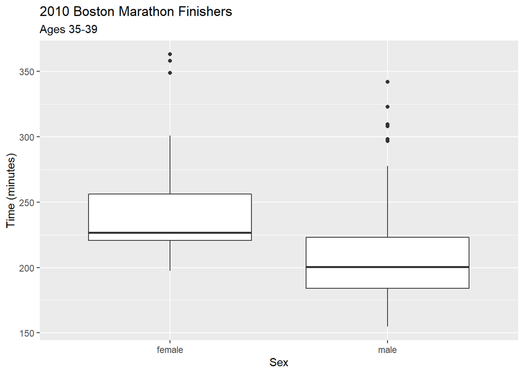

```r
ggplot(bm, aes(x = Sex, y = Time)) +
  geom_boxplot() +
  ylab("Time (minutes)") +
  ggtitle("2010 Boston Marathon Finishers",
          subtitle = "Ages 35-39")
```

### Problem 2

Create and display a table with a numerical summary of the data. Calculate the sample size, mean time, standard deviation of the times, and standard error of the mean ($s/\sqrt{n}$) separately for each sex. This table will have one row for each sex.

> SOLUTION

```r
bm_sum = bm %>%
  select(-BibNum) %>%
  group_by(Sex) %>%
  summarize(n = n(), across(everything(), list(mean = mean, sd = sd))) %>%
  mutate(se = Time_sd/sqrt(n))

bm_sum
```

```
## # A tibble: 2 × 7
##   Sex        n Time_mean Time_sd n_mean  n_sd    se
##   <chr>  <int>     <dbl>   <dbl>  <dbl> <dbl> <dbl>
## 1 female    50      242.    39.3     50    NA  5.56
## 2 male      50      213.    44.8     50    NA  6.33
```

### Problem 3

Using the function `t.test()`, construct separate 95% confidence intervals for each sex for the mean time to complete the 2010 Boston Marathon among all competitors of that sex aged 35–39.

> SOLUTION

```r
men = bm %>%
  filter(Sex == "male") %>%
  pull(Time)

women = bm %>%
  filter(Sex == "female") %>%
  pull(Time)

## Men
t.test(men)
```

```
##
##  One Sample t-test
##
## data:  men
## t = 33.691, df = 49, p-value < 2.2e-16
## alternative hypothesis: true mean is not equal to 0
## 95 percent confidence interval:
##  200.6301 226.0819
## sample estimates:
## mean of x
##   213.356
```

```r
## Women
t.test(women)
```

```
##
##  One Sample t-test
##
## data:  women
## t = 43.498, df = 49, p-value < 2.2e-16
## alternative hypothesis: true mean is not equal to 0
## 95 percent confidence interval:
##  230.7624 253.1176
## sample estimates:
## mean of x
##    241.94
```

### Problem 4

Without using the function `t.test()` write code to calculate the end points of the 95% confidence interval for the mean time for women aged 35–39 to complete the 2010 Boston Marathon.

> SOLUTION

```r
tmult = qt(0.975, 49)
tmult
```

```
## [1] 2.009575
```

```r
ci = bm_sum %>%
  filter(Sex == "female") %>%
  mutate(ci_low = Time_mean - tmult * se,
         ci_high = Time_mean + tmult * se)

ci
```

```
## # A tibble: 1 × 9
##   Sex        n Time_mean Time_sd n_mean  n_sd    se ci_low ci_high
##   <chr>  <int>     <dbl>   <dbl>  <dbl> <dbl> <dbl>  <dbl>   <dbl>
## 1 female    50      242.    39.3     50    NA  5.56   231.    253.
```

### Problem 5

Write an interpretation of the confidence interval from the previous problem in context, following course examples.

> SOLUTION

> We are 95% confident that the mean finish time of all female finishers, aged 35–39, of the 2010 Boston Marathon is between 230.76 and 253.12 minutes.